# Beta-diversity of bromeliad communities along environmental gradients

Beta-diversity of bromeliad communities along environmental gradients Gracielle Higino[^1], Melissa Guzmán[^2], Andrew MacDonald[^3] Last compiled on 28 May, 2022

## Context

1. Special things about the database:
   1. **Small scale and large scale** sampling, allowing micro and macroecological analyses. We have bromeliads systems along continental scales - we can test micro and macroclimate effects on species composition, and compare local and continental beta-diversity.
   2. Although **we can not assess beta-diversity of interactions**, we have a good amount of information and results about the relationship between body mass and predation to try and simulate scenarions of varying interactions.

### What do we know about this system

1. No turnover of interactions - **interactions assumed from co-occurrence**
2. Forbidden links - registered on the dataset, results from literature search.
3. Results from previous work of sCaleWebs:
   1. Richer bromeliads have more links per species, as we can see in this plot authored by [@aammd](https://github.com/aammd):

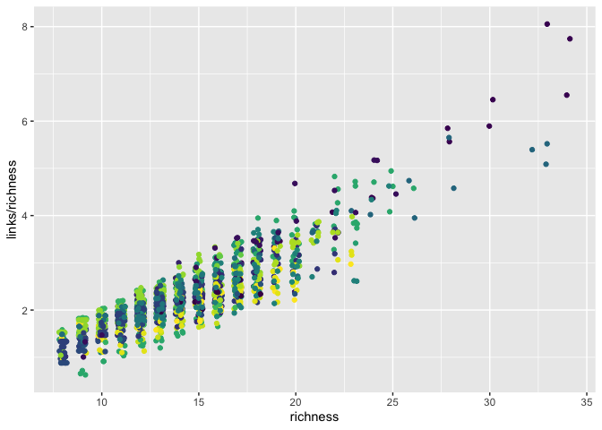

This is very likely the result of the presence of generalist predators in richer communities, as we can see in this plot authored by [@pierrerogy](https://github.com/pierrerogy):

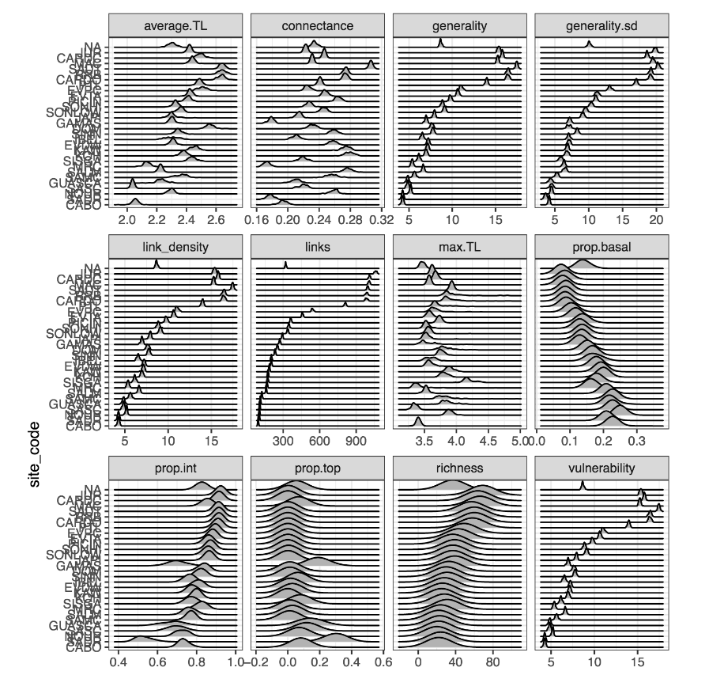

*This plot couldn’t be reproduced, so I pasted a screenshot from this [PDF file](https://github.com/SrivastavaLab/empirical_food_webs/blob/main/dreamzone/modelling_links.pdf).*

## Interesting questions

Many interesting questions came up from our discussions about species and interactions turnover between bromeliads and sites. As we can not evaluate interactions turnover because all interactions are inferred from co-occurrence (in this way, a turnover in species composition necessarily leads to a turnover on interactions), our questions needed to be restricted to those related to species composition, network metrics (also dependent on species composition) and number of links associated with each species.

In this sense, we decided to explore the following questions:

### Species richness and out-degrees

We hypothesized that species richness would be inversely proportional to number of links per species. The rationale behind that is that bromeliads with more species would experience more niche partitioning, and so we would observe more predators interacting with a smaller subset of preys. However, as mentioned above, we could expect this relationship to be the opposite due to the higher probability of recruitment of generalist, highly competitive predators in richer communities.

As this can be an effect of scale, take a look at site-level metrics:

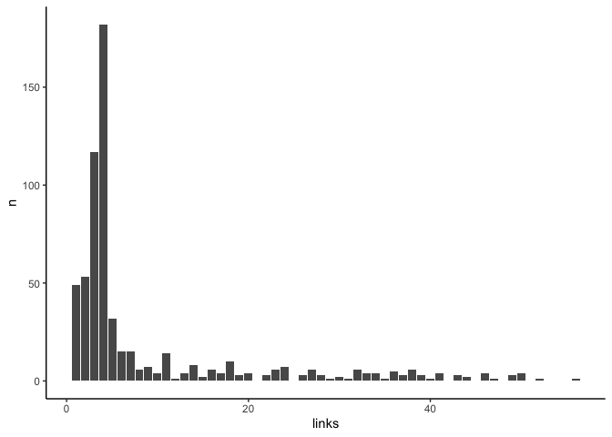

In a related result, the plot below, authored by [@lmguzman](https://github.com/lmguzman), illustrates how the most generalist species contribute less to the composition of local communities, which means they are present in more bromeliads than specialists (as expected); on the other hand, specialist species contribute much more to composition, which might mean that their turn over is more sensitive to local environmental conditions.

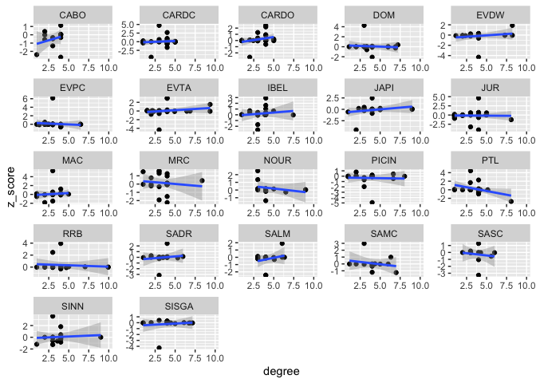

This result is also clear when we plot species contribution to beta-diversity as a function of their out-degrees:

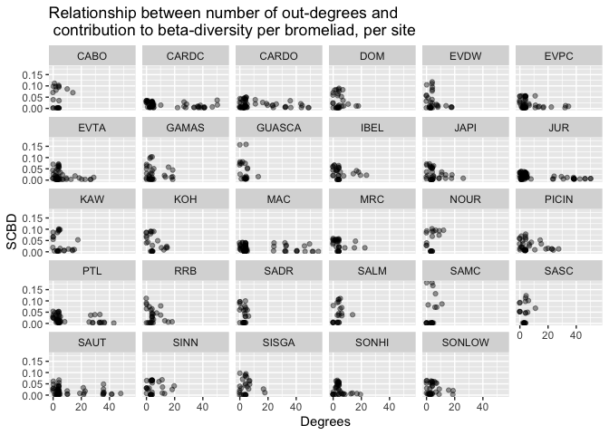

### Degrees and environment

To further investigate the relationship between degrees and environmental filtering, we need to investigate the variation of environmental variables, and find a way to subset a part of the dataset that encompasses a representative part of this variation.

We hypothesize that species with low number of links will be restricted by the environment (which we can assess with spatial autocorrelation analyses and correlations with environmental variables).

### Species richness and network uniqueness

One interesting thing that can be investigated is the relationship between network uniqueness and species richness. [Dansereau et al. 2022](https://onlinelibrary.wiley.com/doi/10.1111/oik.09063) demonstrate in this paper that this relationship varies with geographical scale. We could expect something similar and we have data to test it - from local to continental scales.

### Simulations

[@aammd](https://github.com/aammd) has elaborated on how we can simulate expected data to formulate better hypotheses:

[Click here to see the webpage about simulation](https://scalewebs.github.io/scalewebs-model-simulations/posts/2022-04-13-beta-diversity-and-species-responses/)  
[Run the Shiny App from here](https://github.com/sCaleWebs/scalewebs-model-simulations/blob/main/simulated_network_gradients/app.R)

## Moving forward

The team needs to discuss more deeply the mechanisms that could lead to the patterns we described so far. The team should use the simulations and Shiny App that [@aammd](https://github.com/aammd) created to understand the role of species richness and connectance on network uniqueness.

The project ROADMAP file has scpecific tasks that need to be done to move forward in the project, such as select figures, create legends and join the Zotero library. Contributors interested in co-authoring the paper should request access to the library and to be add to the repository.

Gracielle is happy to contribute to the discussions, but she cannot lead the development of the paper nor should be added as a co-author as she might have conflicts of interest and does not have room to lead yet another project at this moment.

[^1]: University of British Columbia, graciellehigino@gmail.com
[^2]: University of Southern California
[^3]: Université de Sherbrooke